# DS 624: Homwork 10 (Market Basket Analysis)

Analyze Grocery Store Receipts

Donny Lofland

Source Code: https://github.com/djlofland/DATA624_PredictiveAnalytics/tree/master/Homework_10

## Overview

Imagine 10000 receipts sitting on your table. Each receipt represents a transaction with items that were purchased. The receipt is a representation of stuff that went into a customer’s basket - and therefore ‘Market Basket Analysis’.

That is exactly what the Groceries Data Set contains: a collection of receipts with each line representing 1 receipt and the items purchased. Each line is called a transaction and each column in a row represents an item. The data set is attached.

Your assignment is to use R to mine the data for association rules. You should report support, confidence and lift and your top 10 rules by lift.

Extra credit: do a simple cluster analysis on the data as well. Use whichever packages you like. Due May 3 before midnight.

## Load Data

```r
# Load Groceries Dataset
groceries_df <- read.csv("./GroceryDataSet.csv", header = FALSE,
                         na.strings="",
                         stringsAsFactors=FALSE )

# Add an id column
groceries_df$id <- seq(nrow(groceries_df))

# Trim any white space at the begining or end of product names
groceries_df <- groceries_df %>%
  mutate(across(where(is.character), str_trim))

#cols_to_trim <- names(groceries_df)[vapply(groceries_df, is.character, logical(1))]
#groceries_df[,cols_to_trim] <- lapply(groceries_df[,cols_to_trim], trimws)

# How many baskets and max products?
print(paste(nrow(groceries_df), ncol(groceries_df)))
```

```
## [1] "9835 33"
```

```r
# Since the data.frame has empty cells, we need to clean those out
groceries_long <- melt(groceries_df, id.vars="id")
groceries_trans <- as(lapply(split(groceries_long$value, groceries_long$id), unique), "transactions")

# View first few baskets to make sure things look good
inspect(groceries_trans[1:5])
```

```
##     items                      transactionID
## [1] {citrus fruit,
##      margarine,
##      ready soups,
##      semi-finished bread}                  1
## [2] {coffee,
##      tropical fruit,
##      yogurt}                               2
## [3] {whole milk}                           3
## [4] {cream cheese,
##      meat spreads,
##      pip fruit,
##      yogurt}                               4
## [5] {condensed milk,
##      long life bakery product,
##      other vegetables,
##      whole milk}                           5
```

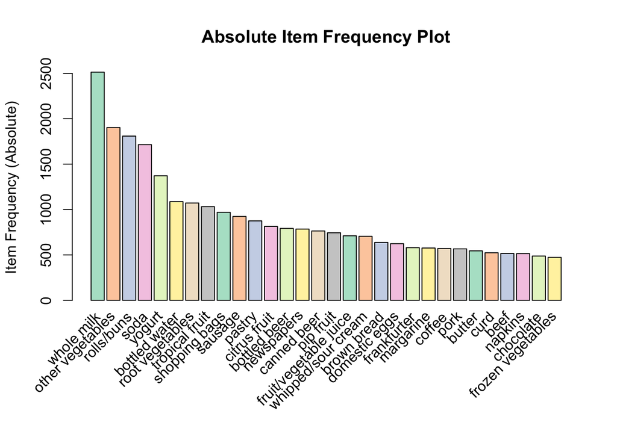

```r
# Plot product frequency for top items

itemFrequencyPlot(groceries_trans,
                  topN=30,
                  type="absolute",
                  col=brewer.pal(8,'Pastel2'),
                  main='Absolute Item Frequency Plot',
                  ylab="Item Frequency (Absolute)")
```

```r
# iFreq <- itemFrequency(groceries_trans, type="relative")
```

### Create Basket Rules

Note: I tried to remove redundant rules using examples from documentation, but for some reason (I don’t know why), the filtering treated ALL rules as redundant. After a fair bit of troubleshooting, I just removed that step for now. This would certainly be something I would circle back to if I were using this analysis for real.

```r
rules <- apriori(groceries_trans,
                 parameter = list(supp = 0.001,
                                  conf = 0.15,
                                  minlen = 2,
                                  maxlen = 5))
```

```
## Apriori
##
## Parameter specification:
##  confidence minval smax arem  aval originalSupport maxtime support minlen
##        0.15    0.1    1 none FALSE            TRUE       5   0.001      2
##  maxlen target  ext
##       5  rules TRUE
##
## Algorithmic control:
##  filter tree heap memopt load sort verbose
##     0.1 TRUE TRUE  FALSE TRUE    2    TRUE
##
## Absolute minimum support count: 9
##
## set item appearances ...[0 item(s)] done [0.00s].
## set transactions ...[169 item(s), 9835 transaction(s)] done [0.00s].
## sorting and recoding items ... [157 item(s)] done [0.00s].
## creating transaction tree ... done [0.00s].
## checking subsets of size 1 2 3 4 5
```

```
##  done [0.01s].
## writing ... [26760 rule(s)] done [0.00s].
## creating S4 object  ... done [0.01s].
```

```r
# find redundant rules
# subset.matrix <- is.subset(rules, rules)
# subset.matrix[lower.tri(subset.matrix, diag=T)] <- NA
# redundant <- colSums(subset.matrix, na.rm=T) >= 1

# remove redundant rules
# rules.pruned <- rules[!redundant]
# rules <- rules.pruned

rules <- sort(rules, by="lift", decreasing=TRUE)
inspect(rules[1:10])
```

```
##      lhs                        rhs                     support confidence coverage lift count
## [1]  {bottled beer,
##       red/blush wine}        => {liquor}                 0.0019       0.40   0.0049   36    19
## [2]  {hamburger meat,
##       soda}                  => {Instant food products}  0.0012       0.21   0.0058   26    12
## [3]  {ham,
##       white bread}           => {processed cheese}       0.0019       0.38   0.0051   23    19
## [4]  {other vegetables,
##       root vegetables,
##       whole milk,
##       yogurt}                => {rice}                   0.0013       0.17   0.0078   22    13
## [5]  {bottled beer,
##       liquor}                => {red/blush wine}         0.0019       0.41   0.0047   21    19
## [6]  {Instant food products,
##       soda}                  => {hamburger meat}         0.0012       0.63   0.0019   19    12
## [7]  {curd,
##       sugar}                 => {flour}                  0.0011       0.32   0.0035   19    11
## [8]  {baking powder,
##       sugar}                 => {flour}                  0.0010       0.31   0.0033   18    10
## [9]  {processed cheese,
##       white bread}           => {ham}                    0.0019       0.46   0.0042   18    19
## [10] {fruit/vegetable juice,
##       ham}                   => {processed cheese}       0.0011       0.29   0.0039   17    11
```

Stepping back, if this were being used in a real setting, I would explore generating a `score` using a geometric mean of `support`, `confidence` and `lift` … then sorting my rules based on this new metric, `score`. Ideally we want rules that are both prevalent and meaningful. A large `lift` with low `support` not be actionable. Alternatively, a high `confidence` with low `support` or low `lift` would also not be as actionable. Ideally, we want rules that identify both high `lift` and high `support`.

Per instructions, I’ve just sorted based on `lift` for now; however, `lift` alone probably isn’t the best approach.

### Visualize Rules

[output not shown]

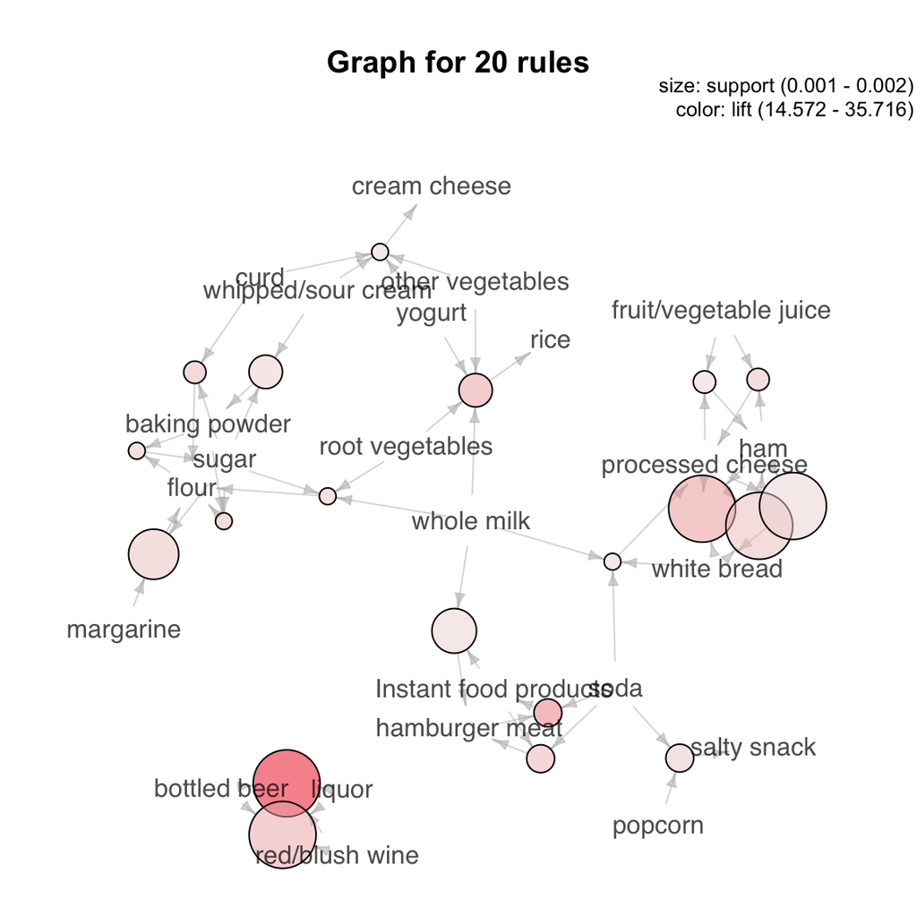

```r
# Sort rules by Confidence
plot(rules[1:20],
     method="graph",
     engine='default',
     control = list(type='items'))
```

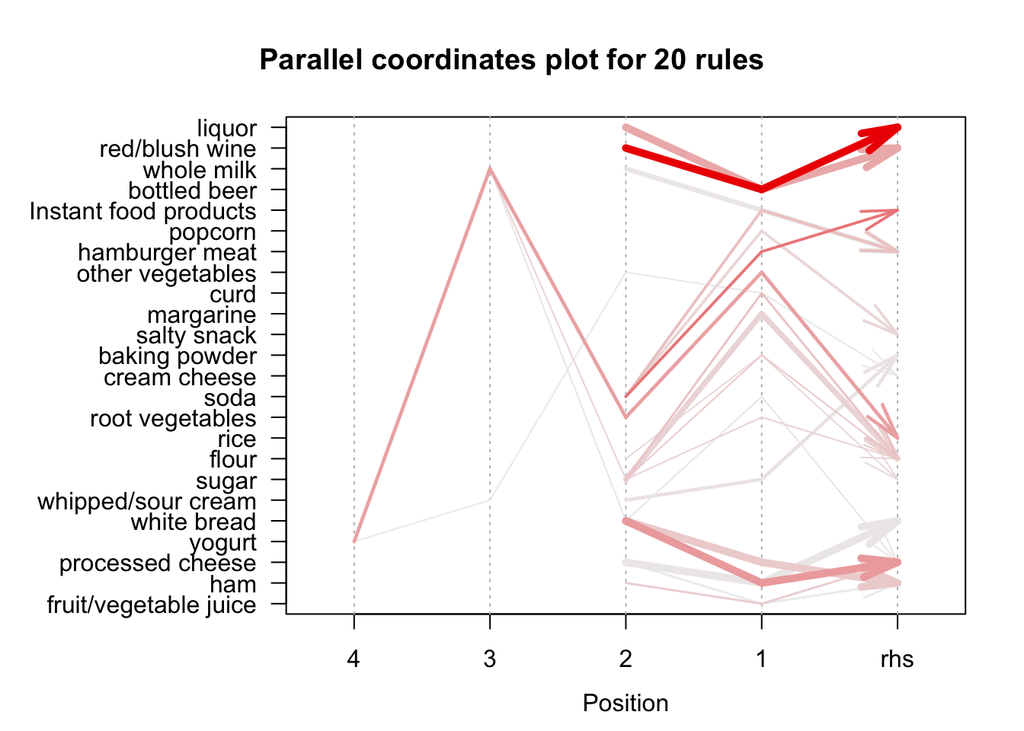

```r
plot(rules[1:20],
     method = "paracoord",
     control = list(reorder = TRUE))
```

### Cluster Analysis

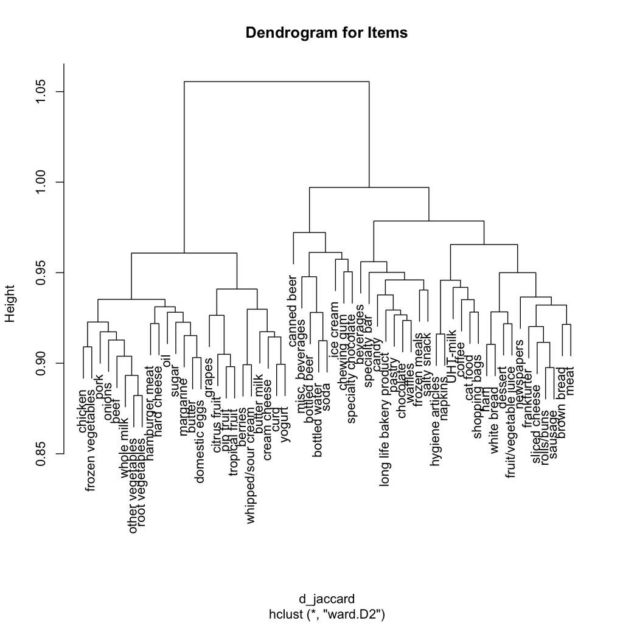

```r
s <- groceries_trans[,itemFrequency(groceries_trans) > 0.02]
d_jaccard <- dissimilarity(s, which = "items", method="affinity")
plot(hclust(d_jaccard, method = "ward.D2"), main = "Dendrogram for Items")
```

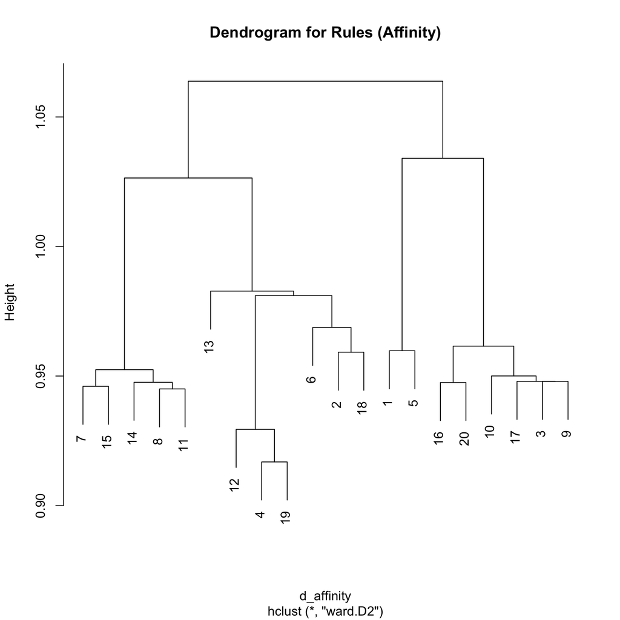

```r
d_affinity <- dissimilarity(rules[1:20],
                            method = "affinity",
                            args = list(transactions = groceries_trans))
hc <- hclust(d_affinity, method = "ward.D2")
plot(hc, main = "Dendrogram for Rules (Affinity)")
```

```r
## create 4 groups and inspect the rules in the first group.
assign <- cutree(hc, k = 3)
inspect(rules[assign == 1])
```

```
##        lhs                            rhs                        support confidence coverage  lift count
## [1]    {bottled beer,
##         red/blush wine}            => {liquor}                    0.0019       0.40   0.0049 35.72    19
## [2]    {bottled beer,
##         liquor}                    => {red/blush wine}            0.0019       0.41   0.0047 21.49    19
## [3]    {Instant food products,
##         rolls/buns}                => {hamburger meat}            0.0010       0.43   0.0023 13.08    10
## [4]    {citrus fruit,
##         fruit/vegetable juice,
##         tropical fruit}            => {grapes}                    0.0011       0.28   0.0040 12.61    11
## [5]    {domestic eggs,
##         other vegetables,
##         yogurt}                    => {soft cheese}               0.0011       0.19   0.0058 11.30    11
## [6]    {cream cheese,
##         other vegetables,
##         whipped/sour cream,
##         yogurt}                    => {curd}                      0.0010       0.59   0.0017 11.04    10
## [7]    {other vegetables,
##         root vegetables,
##         shopping bags}             => {herbs}                     0.0011       0.17   0.0066 10.40    11
## [8]    {butter,
##         other vegetables,
##         root vegetables,
##         whole milk}                => {onions}                    0.0013       0.32   0.0042 10.22    13
## [9]    {fruit/vegetable juice,
##         white bread}               => {processed cheese}          0.0012       0.16   0.0074  9.92    12
## [10]   {butter,
##         napkins,
##         whole milk}                => {hygiene articles}          0.0010       0.32   0.0032  9.79    10
## [11]   {butter,
##         hard cheese,
##         whole milk}                => {whipped/sour cream}        0.0014       0.67   0.0021  9.30    14
## [12]   {domestic eggs,
##         whole milk,
##         yogurt}                    => {soft cheese}               0.0012       0.16   0.0077  9.24    12
## [13]   {sugar,
##         whipped/sour cream,
##         yogurt}                    => {curd}                      0.0010       0.48   0.0021  8.94    10
## [14]   {soda,
##         sugar}                     => {flour}                     0.0011       0.15   0.0073  8.79    11
```

[output cut: 6684 more lines]

[output not shown]